# Introduction to Python Project : FoodHub Data Analysis

### **Question 8**: Which is the most popular cuisine on weekends? [1 mark]

```python
# Filter only weekend orders
weekend_orders = df[df["day_of_the_week"] == "Weekend"]

# Count the number of orders per cuisine
popular_cuisine_weekend = weekend_orders["cuisine_type"].value_counts()

# Print the most popular cuisine
most_popular_cuisine = popular_cuisine_weekend.idxmax()
order_count = popular_cuisine_weekend.max()

print(f"The most popular cuisine on weekends is {most_popular_cuisine} with {order_count} orders.")
```

```
The most popular cuisine on weekends is American with 415 orders.
```

#### Observations:

- Tha most popular cuisine on weekends is American cuisine.
- American cuisine received the highest number of orders on weekends.
- Other cuisines, such as Japanese and Mexican, were also widely ordered.
- It means that customers prefer fast food, burgers, and comfort meals during weekends.

### **Question 9**: What percentage of the orders cost more than 20 dollars? [2 marks]

```python
total_orders = len(df)  # Count the total number of orders

high_cost_orders = (df["cost_of_the_order"] > 20).sum() # Count the number of orders where cost > 20

percentage = (high_cost_orders / total_orders) * 100   # Calculate percentage

print(f"Percentage of orders costing more than $20: {percentage:.2f}%")
```

```
Percentage of orders costing more than $20: 29.24%
```

#### Observations:

- Total orders-1,898
- Cost more than $20- 555 orders
- 29.24% of the orders cost more than $20

### **Question 10**: What is the mean order delivery time? [1 mark]

```python
mean_delivery_time = df["delivery_time"].mean() # Calculate the average delivery time
print(f"Mean order delivery time: {mean_delivery_time:.2f} minutes")
```

```
Mean order delivery time: 24.16 minutes
```

### **Question 11:** The company has decided to give 20% discount vouchers to the top 3 most frequent customers. Find the IDs of these customers and the number of orders they placed. [1 mark]

```python
# Count the number of orders per customer
top_customers = df["customer_id"].value_counts().head(3)

print("Top 3 most frequent customers and their order counts:")   # Print the result
print(top_customers)
```

```
Top 3 most frequent customers and their order counts:
customer_id
52832    13
47440    10
83287     9
Name: count, dtype: int64
```

### **Question 12**: Perform a multivariate analysis to explore relationships between the important variables in the dataset. (It is a good idea to explore relations between numerical variables as well as relations between numerical and categorical variables) [10 marks]

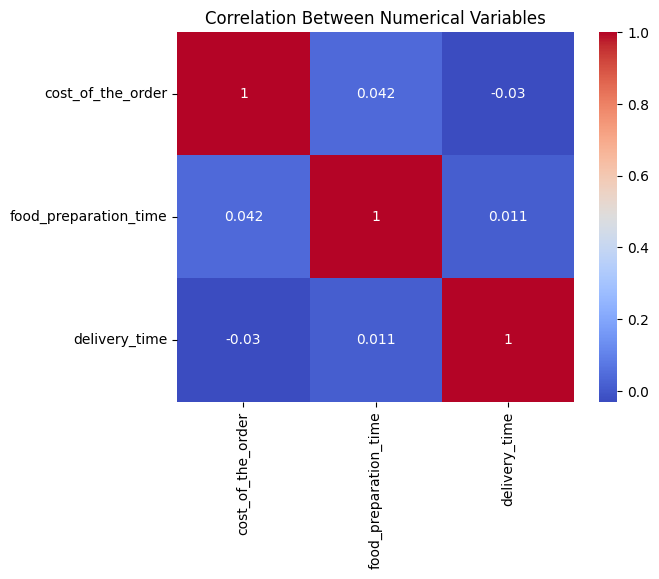

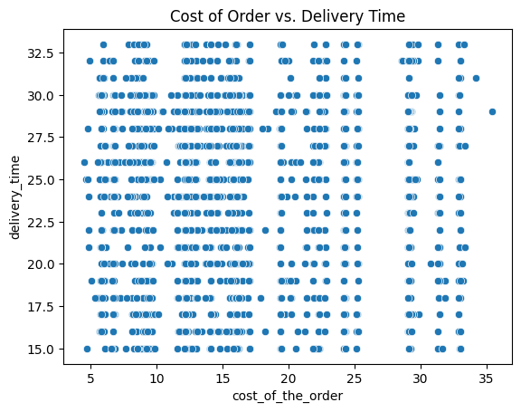

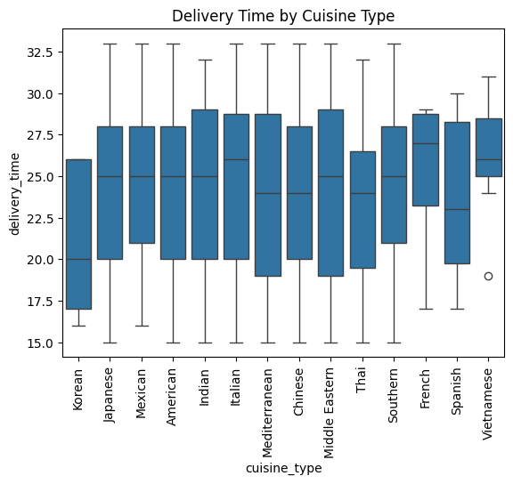

```python
# **1. Correlation Heatmap (Numerical Variables)**
sns.heatmap(df[['cost_of_the_order', 'food_preparation_time', 'delivery_time']].corr(), annot=True, cmap="coolwarm")
plt.title("Correlation Between Numerical Variables")
plt.show()

# **2. Scatter Plot (Cost vs. Delivery Time)**
sns.scatterplot(x=df["cost_of_the_order"], y=df["delivery_time"])
plt.title("Cost of Order vs. Delivery Time")
plt.show()

# **3. Boxplot (Delivery Time by Cuisine Type)**
sns.boxplot(x=df["cuisine_type"], y=df["delivery_time"])
plt.xticks(rotation=90)
plt.title("Delivery Time by Cuisine Type")
plt.show()
```

### Observations:

#### 1.Numerical Correlation:-

- Weak link between food preparation time and delivery time (not always longer).
- Cost of the order does not strongly affect delivery or preparation time

#### 2.Scatter Plot (Cost vs. Delivery Time)

- Higher-cost orders don’t always take longer.
- Some expensive meals have slower delivery (possible bulk or complex orders).

### **Question 13:** The company wants to provide a promotional offer in the advertisement of the restaurants. The condition to get the offer is that the restaurants must have a rating count of more than 50 and the average rating should be greater than 4. Find the restaurants fulfilling the criteria to get the promotional offer. [3 marks]

```python
# rating column containing string values, Convert rating column to numeric (if some values are stored as strings), or else it will give the error
df["rating"] = pd.to_numeric(df["rating"], errors="coerce")  # Convert non-numeric values to NaN

# Group by restaurant and calculate rating count & average rating
restaurant_ratings = df.groupby("restaurant_name")["rating"].agg(["count", "mean"])

# Apply conditions: Rating count > 50 and average rating > 4
eligible_restaurants = restaurant_ratings[(restaurant_ratings["count"] > 50) & (restaurant_ratings["mean"] > 4)]

# Print eligible restaurants
print("Restaurants eligible for the promotional offer:")
print(eligible_restaurants)
```

```
Restaurants eligible for the promotional offer:
                           count      mean
restaurant_name
Blue Ribbon Fried Chicken     64  4.328125
Blue Ribbon Sushi             73  4.219178
Shake Shack                  133  4.278195
The Meatball Shop             84  4.511905
```

#### Observations:

- 4 restaurants are eligible for the promotional offer.
- Shake shake restaurant has a highest count with averate of 4.27ratings.
- Restaurants that qualify for the promotional offer can benefit from better visibility, customer trust, and increased sales.
- If a restaurant has a high rating count but a lower average rating, it might indicate inconsistency in service or food quality.
- These 4 restaurant are likely customer favorites, making them ideal for advertising.

### **Question 14:** The company charges the restaurant 25% on the orders having cost greater than 20 dollars and 15% on the orders having cost greater than 5 dollars. Find the net revenue generated by the company across all orders. [3 marks]

```python
# Calculate revenue for orders > $20 (apply 25% charge)
high_cost_orders = df[df["cost_of_the_order"] > 20]
high_cost_revenue = (high_cost_orders["cost_of_the_order"] * 0.25).sum()

# Calculate revenue for orders > $5 (apply 15% charge)
mid_cost_orders = df[(df["cost_of_the_order"] > 5) & (df["cost_of_the_order"] <= 20)]
mid_cost_revenue = (mid_cost_orders["cost_of_the_order"] * 0.15).sum()

# Calculate total revenue
total_revenue = high_cost_revenue + mid_cost_revenue

print(f"Net revenue generated by the company: ${total_revenue:.2f}")
```

```
Net revenue generated by the company: $6166.30
```

#### Observations:

- The company earns a higher share (25%) from premium orders ($20+), contributing more revenue.
- Orders between $5 and $20 contribute a moderate amount at 15% charge.
- The total revenue is the sum of both charges from all orders is $6166.30

### **Question 15:** The company wants to analyze the total time required to deliver the food. What percentage of orders take more than 60 minutes to get delivered from the time the order is placed? (The food has to be prepared and then delivered.) [2 marks]

```python
# Calculate total time (preparation time + delivery time)
df["total_time"] = df["food_preparation_time"] + df["delivery_time"]

total_orders = len(df)   # Count total orders

long_orders = (df["total_time"] > 60).sum()  # Count orders taking more than 60 minutes

percentage = (long_orders / total_orders) * 100  # Calculate percentage

print(f"Percentage of orders taking more than 60 minutes: {percentage:.2f}%")
```

```
Percentage of orders taking more than 60 minutes: 10.54%
```

#### Observations:

10.54% orders take more than 60 minutes to be prepared and delivered.

- This could be due to complex meals, peak-hour delays, or restaurant efficiency.
- Reducing long delivery times can improve customer satisfaction.
- If too many orders exceed 60 minutes, the company could optimize delivery efficiency to improve customer satisfaction.

### **Question 16:** The company wants to analyze the delivery time of the orders on weekdays and weekends. How does the mean delivery time vary during weekdays and weekends? [2 marks]

```python
# Calculate mean delivery time for weekdays
weekday_mean = df[df["day_of_the_week"] == "Weekday"]["delivery_time"].mean()

# Calculate mean delivery time for weekends
weekend_mean = df[df["day_of_the_week"] == "Weekend"]["delivery_time"].mean()

print(f"Mean delivery time on weekdays: {weekday_mean:.2f} minutes")
print(f"Mean delivery time on weekends: {weekend_mean:.2f} minutes")
```

```
Mean delivery time on weekdays: 28.34 minutes
Mean delivery time on weekends: 22.47 minutes
```

#### Observations:

- weekday deliveries take longer time, office rush hours and possible traffic delays.
- weekend deliveries is faster maybe there is less traffic.
- The difference in mean delivery time suggests that the company could optimize weekdays logistics to improve customer satisfaction.

### Conclusion and Recommendations

### **Question 17:** What are your conclusions from the analysis? What recommendations would you like to share to help improve the business? (You can use cuisine type and feedback ratings to drive your business recommendations.) [6 marks]

## Conclusions:

### 1.Order Cost Trends

- About 29% of the orders are above $20, which helps the company earn a higher 25% commission.
- Most orders cost between $5 and $30, and expensive orders bring in more revenue.

### 3.Customer Preferences & Ratings

- American cuisine is the most popular, especially on weekends.
- Some restaurants qualify for promotions with more than 50 ratings and an average rating above 4.0.
- However, many orders have missing ratings, affecting customer feedback analysis.

### 5.Top Customers & Restaurants

- The top 3 most frequent customers placed multiple orders and can be rewarded with discount vouchers.
- Shake Shack and Blue Ribbon Fried Chicken are among the most ordered restaurants, suggesting strong customer preference.

### 6.Final Conclusion

- Speeding up deliveries and encouraging more customer reviews can help improve satisfaction.
- Promoting higher-priced meals and popular cuisines like American and Japanese can boost revenue.
- Offering loyalty programs and discounts to repeat customers can build stronger relationships.

### Recommendations:

#### 1.Improve Delivery Speed

- Work on cutting delivery delays during weekdays by adding more staff or working with faster delivery partners.
- Find out which restaurants take too long to prepare food and help them speed up their kitchen processes.

#### 2.Get More Customer Feedback

- Ask customers to leave ratings and reviews after every order, so it's easier to track restaurant performance.
- Encourage customers to leave ratings and feedback, reducing the number of "Not given" reviews.
- Give special offers to restaurants that consistently get good reviews to keep customers happy.
- Offer compensation or give discounts for late deliveries to maintain a positive customer experience.

#### 4.Boost Sales and Revenue

- Promote higher-priced meals (especially those over $20) because they bring in more profit through service charges.
- Advertise popular cuisines like American and Japanese, which attract more customers.
- Create special weekend deals for high-value orders to encourage spending.

#### 5.Keep Loyal Customers Happy

- Give repeat customers special discounts to make them feel valued and keep them coming back.
- Start a loyalty program to encourage frequent ordering and build a stronger customer base.

#### 6.Strengthen Restaurant Partnerships

- Provide performance reports to restaurants so they can improve food preparation and service.
- Recommend menu optimization based on high-selling dishes to increase efficiency